# GRF Subgroup Identification: dmin.grf Calibration for Binary Endpoints

- Show All Code
- Hide All Code
- View Source

Systematic Evaluation of Detection Power and FPR Control

Author

Larry F. León

Published

April 11, 2026

# 1 Purpose

`grf.subg.harm.glm()` uses `causal_forest()` for candidate factor screening and policy trees for subgroup identification. The `dmin.grf` parameter sets the minimum absolute CATE (conditional average treatment effect) difference required for a policy tree node to be considered valid.

For binary outcomes, the CATE is on the **risk difference** scale:

$$\text{CATE}(x) = P(Y=1 \mid T=1, X=x) - P(Y=1 \mid T=0, X=x)$$

## 1.1 Design

The evaluation proceeds in three phases:

1. **Configuration discovery**: Test all combinations of treatment switching and `adverse_outcome` to identify which GRF configuration correctly detects the planted subgroup Q for each of four binary scenario types.
2. **dmin.grf sweep**: For each working configuration, evaluate detection and FPR across 10 values of `dmin.grf` at three effect sizes (weak, moderate, strong).
3. **Summary**: Identify optimal `dmin.grf` per scenario and produce detection–FPR tradeoff curves.

# 2 Setup

```r
library(forestsearch)
library(survival)
library(data.table)
library(ggplot2)
library(gt)
library(doFuture)
library(foreach)

plan(multisession, workers = n_workers)
cat(sprintf("Workers: %d\n", n_workers))
```

```
#> Workers: 115
```

```r
reset_workers <- function(msg = "") {
  if (nzchar(msg)) cat(sprintf("[Resetting workers: %s]\n", msg))
  plan(sequential); gc(verbose = FALSE); Sys.sleep(1)
  plan(multisession, workers = n_workers)
}

t_start <- proc.time()
```

# 3 Synthetic Data

```r
set.seed(42)
syn <- data.frame(
  id = seq_len(N_syn), treat = rep(0:1, each = N_syn / 2),
  z1 = as.factor(sample(0:1, N_syn, TRUE)),
  z2 = as.factor(sample(0:1, N_syn, TRUE)),
  z3 = as.factor(sample(0:1, N_syn, TRUE)),
  z4 = as.factor(sample(0:1, N_syn, TRUE))
)
in_Q <- syn$z1 == 1 & syn$z2 == 1
syn$treat_sw <- 1L - syn$treat
cat(sprintf("Synthetic data: N=%d, Q prevalence=%.1f%%\n",
    N_syn, 100 * mean(in_Q)))
```

```
#> Synthetic data: N=1200, Q prevalence=25.0%
```

Four binary outcome scenarios, each with a planted subgroup Q = {z1 == 1 & z2 == 1}:

```r
# (A) Harm + Adverse: treatment INCREASES bad outcome for Q
syn$y_harm_adv <- rbinom(N_syn, 1,
  ifelse(syn$treat == 1 & in_Q, 0.65,
    ifelse(syn$treat == 1, 0.22, 0.35)))

# (B) Harm + Positive: treatment REDUCES good outcome for Q
syn$y_harm_pos <- rbinom(N_syn, 1,
  ifelse(syn$treat == 1 & in_Q, 0.15,
    ifelse(syn$treat == 1, 0.55, 0.40)))

# (C) Benefit + Positive: treatment INCREASES good outcome MORE for Q
syn$y_ben_pos <- rbinom(N_syn, 1,
  ifelse(syn$treat == 1 & in_Q, 0.80,
    ifelse(syn$treat == 1, 0.50, 0.40)))

# (D) Benefit + Adverse: treatment REDUCES bad outcome MORE for Q
syn$y_ben_adv <- rbinom(N_syn, 1,
  ifelse(syn$treat == 1 & in_Q, 0.10,
    ifelse(syn$treat == 1, 0.33, 0.38)))

# Summary
cat("Raw CATE (risk difference) for Q:\n")
```

```
#> Raw CATE (risk difference) for Q:
```

```r
for (nm in c("y_harm_adv", "y_harm_pos", "y_ben_pos", "y_ben_adv")) {
  rd_Q  <- mean(syn[[nm]][in_Q & syn$treat == 1]) -
           mean(syn[[nm]][in_Q & syn$treat == 0])
  rd_Qc <- mean(syn[[nm]][!in_Q & syn$treat == 1]) -
           mean(syn[[nm]][!in_Q & syn$treat == 0])
  cat(sprintf("  %s: RD(Q)=%+.3f, RD(Qc)=%+.3f, diff=%.3f\n",
      nm, rd_Q, rd_Qc, abs(rd_Q - rd_Qc)))
}
```

```
#>   y_harm_adv: RD(Q)=+0.361, RD(Qc)=-0.172, diff=0.532
#>   y_harm_pos: RD(Q)=-0.266, RD(Qc)=+0.156, diff=0.422
#>   y_ben_pos: RD(Q)=+0.448, RD(Qc)=+0.070, diff=0.379
#>   y_ben_adv: RD(Q)=-0.340, RD(Qc)=-0.025, diff=0.315
```

# 4 Phase 1: Configuration Discovery

GRF identifies the subgroup with the **most negative CATE** as “harm.” For adverse outcomes (higher Y = worse), this convention is inverted — negative CATE means treatment *reduces* the bad outcome, which is beneficial.

Two mechanisms can fix this:

- `adverse_outcome = TRUE`: flips Y to 1−Y before GRF
- **Treatment switching**: negates the CATE directly

This phase tests all 16 combinations (4 scenarios × 2 treatment directions × 2 adverse_outcome settings) to empirically determine which produces correct detection.

```r
test_config <- function(scenario, y_col, treat_col, adverse_outcome) {
  res <- tryCatch(
    grf.subg.harm.glm(
      data = syn, confounders.name = confounders,
      outcome.name = y_col, treat.name = treat_col, id.name = "id",
      outcome_type = "binary", adverse_outcome = adverse_outcome,
      n.min = 40L, dmin.grf = 0, maxdepth = 2L, RCT = TRUE,
      sg.criterion = "mDiff", seedit = 42L, verbose = FALSE
    ),
    error = function(e) NULL
  )

  if (is.null(res) || is.null(res$sg.harm.id) ||
      length(res$sg.harm.id) == 0 || all(is.na(res$sg.harm.id))) {
    return(data.frame(Scenario = scenario, Treatment = treat_col,
      Adverse_Outcome = adverse_outcome, Detected = FALSE,
      Sensitivity = NA_real_, PPV = NA_real_,
      Subgroup = "", stringsAsFactors = FALSE))
  }

  in_H <- res$data$treat.recommend == 0
  tp <- sum(in_H & in_Q); fp <- sum(in_H & !in_Q)
  fn <- sum(!in_H & in_Q)
  sens <- tp / max(tp + fn, 1)
  ppv  <- tp / max(tp + fp, 1)

  data.frame(Scenario = scenario, Treatment = treat_col,
    Adverse_Outcome = adverse_outcome, Detected = TRUE,
    Sensitivity = round(sens, 2), PPV = round(ppv, 2),
    Subgroup = paste(res$sg.harm.id, collapse = " & "),
    stringsAsFactors = FALSE)
}

# Test all 16 combinations
configs <- list()
for (scen in list(
  list(name = "Harm+Adverse", y = "y_harm_adv"),
  list(name = "Harm+Positive", y = "y_harm_pos"),
  list(name = "Benefit+Positive", y = "y_ben_pos"),
  list(name = "Benefit+Adverse", y = "y_ben_adv")
)) {
  for (tr in c("treat", "treat_sw")) {
    for (ao in c(FALSE, TRUE)) {
      configs[[length(configs) + 1]] <- test_config(
        scen$name, scen$y, tr, ao)
    }
  }
}

config_df <- do.call(rbind, configs)
```

## 4.1 Full Configuration Results

```r
config_df |>
  gt::gt() |>
  gt::tab_header(
    title = "GRF Configuration Discovery",
    subtitle = sprintf("N=%d, Q={z1==1 & z2==1}, dmin.grf=0", N_syn)
  ) |>
  gt::tab_style(
    style = gt::cell_fill(color = "#c8e6c9"),
    locations = gt::cells_body(
      rows = Detected & !is.na(Sensitivity) & Sensitivity >= 0.5)
  ) |>
  gt::tab_style(
    style = gt::cell_fill(color = "#ffcdd2"),
    locations = gt::cells_body(
      rows = !Detected | is.na(Sensitivity) | Sensitivity < 0.5)
  ) |>
  gt::tab_footnote(
    footnote = "Green = correctly identifies Q (Sens >= 0.50). Red = wrong subgroup or no detection."
  )
```

GRF Configuration Discovery

N=1200, Q={z1==1 & z2==1}, dmin.grf=0

| Scenario | Treatment | Adverse_Outcome | Detected | Sensitivity | PPV | Subgroup |
| --- | --- | --- | --- | --- | --- | --- |
| Harm+Adverse | treat | FALSE | TRUE | 0 | 0.00 | z2 <= 0 |
| Harm+Adverse | treat | TRUE | TRUE | 0 | 0.00 | z2 <= 0 |
| Harm+Adverse | treat_sw | FALSE | TRUE | 1 | 1.00 | z1 <= 0 & z2 <= 0 |
| Harm+Adverse | treat_sw | TRUE | TRUE | 1 | 1.00 | z1 <= 0 & z2 <= 0 |
| Harm+Positive | treat | FALSE | TRUE | 1 | 1.00 | z2 <= 0 & z1 <= 0 |
| Harm+Positive | treat | TRUE | TRUE | 1 | 1.00 | z2 <= 0 & z1 <= 0 |
| Harm+Positive | treat_sw | FALSE | TRUE | 0 | 0.00 | z1 <= 0 |
| Harm+Positive | treat_sw | TRUE | TRUE | 0 | 0.00 | z1 <= 0 |
| Benefit+Positive | treat | FALSE | TRUE | 0 | 0.00 | z1 <= 0 & z4 <= 0 |
| Benefit+Positive | treat | TRUE | TRUE | 0 | 0.00 | z1 <= 0 & z4 <= 0 |
| Benefit+Positive | treat_sw | FALSE | TRUE | 1 | 0.33 | z1 <= 0 & z4 <= 0 |
| Benefit+Positive | treat_sw | TRUE | TRUE | 1 | 0.33 | z1 <= 0 & z4 <= 0 |
| Benefit+Adverse | treat | FALSE | TRUE | 1 | 0.50 | z1 <= 0 |
| Benefit+Adverse | treat | TRUE | TRUE | 1 | 0.50 | z1 <= 0 |
| Benefit+Adverse | treat_sw | FALSE | TRUE | 0 | 0.00 | z3 <= 0 & z1 <= 0 |
| Benefit+Adverse | treat_sw | TRUE | TRUE | 0 | 0.00 | z3 <= 0 & z1 <= 0 |

Green = correctly identifies Q (Sens >= 0.50). Red = wrong subgroup or no detection.

## 4.2 Best Configuration per Scenario

```r
best_configs <- list()
best_df <- data.frame()

for (scen in unique(config_df$Scenario)) {
  sub <- config_df[config_df$Scenario == scen & config_df$Detected &
                     !is.na(config_df$Sensitivity), ]
  if (nrow(sub) == 0) next
  best <- sub[which.max(sub$Sensitivity), ]
  best_configs[[scen]] <- best
  best_df <- rbind(best_df, best)
}

best_df |>
  gt::gt() |>
  gt::tab_header(
    title = "Recommended GRF Configuration per Scenario",
    subtitle = "Highest sensitivity configuration"
  ) |>
  gt::tab_style(
    style = gt::cell_text(weight = "bold"),
    locations = gt::cells_body(columns = Sensitivity)
  )
```

Recommended GRF Configuration per Scenario

Highest sensitivity configuration

| Scenario | Treatment | Adverse_Outcome | Detected | Sensitivity | PPV | Subgroup |
| --- | --- | --- | --- | --- | --- | --- |
| Harm+Adverse | treat_sw | FALSE | TRUE | 1 | 1.00 | z1 <= 0 & z2 <= 0 |
| Harm+Positive | treat | FALSE | TRUE | 1 | 1.00 | z2 <= 0 & z1 <= 0 |
| Benefit+Positive | treat_sw | FALSE | TRUE | 1 | 0.33 | z1 <= 0 & z4 <= 0 |
| Benefit+Adverse | treat | FALSE | TRUE | 1 | 0.50 | z1 <= 0 |

# 5 Phase 2: dmin.grf Sweep

For each working configuration from Phase 1, we evaluate 10 values of `dmin.grf` at 3 effect sizes, using 1500 alt + 1500 null simulations (N=800) per grid point.

```r
run_dmin_eval <- function(dgm, nsims, dmin_val, adverse_outcome) {
  results_raw <- foreach(
    i = seq_len(nsims),
    .errorhandling = "pass",
    .options.future = list(
      packages = c("forestsearch", "survival", "data.table"),
      seed = TRUE
    )
  ) %dofuture% {
    sim_df <- simulate_from_glm_dgm(dgm, n = sim_n,
                                     seed = sim_seed + i * 1000L)
    res <- tryCatch(
      grf.subg.harm.glm(
        data = sim_df, confounders.name = confounders,
        outcome.name = "y_sim", treat.name = "treat_sim",
        id.name = "id", outcome_type = "binary",
        adverse_outcome = adverse_outcome,
        n.min = 40L, dmin.grf = dmin_val, maxdepth = 2L,
        RCT = TRUE, sg.criterion = "mDiff", seedit = 42L,
        verbose = FALSE
      ),
      error = function(e) NULL
    )
    detected <- !is.null(res) && !is.null(res$sg.harm.id) &&
      length(res$sg.harm.id) > 0 && !all(is.na(res$sg.harm.id))
    detected
  }

  # Handle any errors from foreach
  is_err <- vapply(results_raw, inherits, logical(1), "error")
  good <- unlist(results_raw[!is_err])
  100 * sum(good) / nsims
}

# Scenario DGM specs
scenario_specs <- list(
  list(name = "Harm+Adverse", y_alt = "y_harm_adv",
       null_rates = c(treat = 0.22, ctrl = 0.35)),
  list(name = "Harm+Positive", y_alt = "y_harm_pos",
       null_rates = c(treat = 0.55, ctrl = 0.40)),
  list(name = "Benefit+Positive", y_alt = "y_ben_pos",
       null_rates = c(treat = 0.55, ctrl = 0.40)),
  list(name = "Benefit+Adverse", y_alt = "y_ben_adv",
       null_rates = c(treat = 0.22, ctrl = 0.35))
)
```

```r
sweep_results <- data.frame(
  Scenario = character(0), Effect_Size = character(0),
  k_inter = numeric(0), OR_Q = numeric(0),
  dmin = numeric(0), Det_H1 = numeric(0), FPR_H0 = numeric(0),
  stringsAsFactors = FALSE
)

cat(sprintf("dmin.grf grid: %s\n", paste(dmin_grid, collapse = ", ")))
```

```
#> dmin.grf grid: 0, 0.02, 0.05, 0.08, 0.1, 0.12, 0.15, 0.2, 0.25, 0.3
```

```r
cat(sprintf("Effect sizes: %s\n",
    paste(sprintf("%s (k=%.1f)", names(k_inter_levels), k_inter_levels),
          collapse = ", ")))
```

```
#> Effect sizes: weak (k=0.8), moderate (k=1.5), strong (k=2.5)
```

```r
cat(sprintf("Sims per point: %d alt + %d null, N=%d\n\n", nsims, nsims, sim_n))
```

```
#> Sims per point: 1500 alt + 1500 null, N=800
```

```r
for (spec in scenario_specs) {
  scen_name <- spec$name
  if (!scen_name %in% names(best_configs)) {
    cat(sprintf("--- Skipping %s (no working config) ---\n\n", scen_name))
    next
  }

  bc <- best_configs[[scen_name]]
  treat_col <- bc$Treatment
  adverse_out <- bc$Adverse_Outcome

  cat(sprintf("=== %s (treat=%s, adverse_outcome=%s) ===\n",
      scen_name, treat_col, adverse_out))

  # Reset workers at start of each scenario to prevent memory buildup
  reset_workers(scen_name)

  # Create null outcome
  y_null_col <- paste0("y_null_", gsub("\\+", "", scen_name))
  syn[[y_null_col]] <- rbinom(N_syn, 1,
    ifelse(syn[[treat_col]] == 1,
           spec$null_rates["treat"], spec$null_rates["ctrl"]))

  for (es_name in names(k_inter_levels)) {
    k_val <- k_inter_levels[es_name]

    dgm_alt <- tryCatch(
      generate_glm_dgm(
        syn, confounders, spec$y_alt, treat_col, "binary", "OR",
        subgroup_vars = c("z1", "z2"),
        subgroup_cuts = list(z1 = 1L, z2 = 1L),
        model = "alt", k_inter = k_val,
        n_super = dgm_n_super, seed = sim_seed),
      error = function(e) NULL)

    dgm_null <- tryCatch(
      generate_glm_dgm(
        syn, confounders, y_null_col, treat_col, "binary", "OR",
        subgroup_vars = c("z1", "z2"),
        subgroup_cuts = list(z1 = 1L, z2 = 1L),
        model = "null", k_treat = 1,
        n_super = dgm_n_super, seed = sim_seed),
      error = function(e) NULL)

    if (is.null(dgm_alt) || is.null(dgm_null)) next

    or_Q <- dgm_alt$hazard_ratios$harm_subgroup
    cat(sprintf("  %s (k=%.1f): OR(Q)=%.2f\n", es_name, k_val, or_Q))

    for (dmin_val in dmin_grid) {
      det <- run_dmin_eval(dgm_alt, nsims, dmin_val, adverse_out)
      fpr <- run_dmin_eval(dgm_null, nsims, dmin_val, adverse_out)

      sweep_results[nrow(sweep_results) + 1, ] <- data.frame(
        Scenario = scen_name, Effect_Size = es_name,
        k_inter = k_val, OR_Q = round(or_Q, 2),
        dmin = dmin_val, Det_H1 = det, FPR_H0 = fpr,
        stringsAsFactors = FALSE)

      flag <- if (det >= target_det && fpr <= target_fpr) " ***" else ""
      cat(sprintf("    dmin=%.2f: Det=%3.0f%%, FPR=%3.0f%%%s\n",
          dmin_val, det, fpr, flag))
    }
    cat("\n")
  }
  cat("\n")
}
```

```
#> === Harm+Adverse (treat=treat_sw, adverse_outcome=FALSE) ===
#> [Resetting workers: Harm+Adverse]
#>   weak (k=0.8): OR(Q)=2.61
#>     dmin=0.00: Det= 86%, FPR= 23%
#>     dmin=0.02: Det= 73%, FPR= 23%
#>     dmin=0.05: Det= 42%, FPR= 23%
#>     dmin=0.08: Det= 18%, FPR= 23%
#>     dmin=0.10: Det=  9%, FPR= 22%
#>     dmin=0.12: Det=  4%, FPR= 19%
#>     dmin=0.15: Det=  1%, FPR= 12%
#>     dmin=0.20: Det=  0%, FPR=  1%
#>     dmin=0.25: Det=  0%, FPR=  0%
#>     dmin=0.30: Det=  0%, FPR=  0%
#>
#>   moderate (k=1.5): OR(Q)=5.25
#>     dmin=0.00: Det= 85%, FPR= 23%
#>     dmin=0.02: Det= 71%, FPR= 23%
#>     dmin=0.05: Det= 41%, FPR= 23%
#>     dmin=0.08: Det= 18%, FPR= 23%
#>     dmin=0.10: Det=  9%, FPR= 22%
#>     dmin=0.12: Det=  4%, FPR= 19%
#>     dmin=0.15: Det=  1%, FPR= 12%
#>     dmin=0.20: Det=  0%, FPR=  1%
#>     dmin=0.25: Det=  0%, FPR=  0%
#>     dmin=0.30: Det=  0%, FPR=  0%
#>
#>   strong (k=2.5): OR(Q)=14.27
#>     dmin=0.00: Det= 84%, FPR= 23%
#>     dmin=0.02: Det= 71%, FPR= 23%
#>     dmin=0.05: Det= 42%, FPR= 23%
#>     dmin=0.08: Det= 18%, FPR= 23%
#>     dmin=0.10: Det=  9%, FPR= 22%
#>     dmin=0.12: Det=  4%, FPR= 19%
#>     dmin=0.15: Det=  1%, FPR= 12%
#>     dmin=0.20: Det=  0%, FPR=  1%
#>     dmin=0.25: Det=  0%, FPR=  0%
#>     dmin=0.30: Det=  0%, FPR=  0%
#>
#>
#> === Harm+Positive (treat=treat, adverse_outcome=FALSE) ===
```

[output cut: 99 more lines]

```
#>     dmin=0.20: Det=  7%, FPR=  1%
#>     dmin=0.25: Det=  1%, FPR=  0%
#>     dmin=0.30: Det=  0%, FPR=  0%
#>
#>   strong (k=2.5): OR(Q)=7.42
#>     dmin=0.00: Det=100%, FPR= 20%
#>     dmin=0.02: Det=100%, FPR= 20%
#>     dmin=0.05: Det=100%, FPR= 20%
#>     dmin=0.08: Det= 94%, FPR= 20%
#>     dmin=0.10: Det= 85%, FPR= 20%
#>     dmin=0.12: Det= 67%, FPR= 18%
#>     dmin=0.15: Det= 39%, FPR= 11%
#>     dmin=0.20: Det=  7%, FPR=  1%
#>     dmin=0.25: Det=  1%, FPR=  0%
#>     dmin=0.30: Det=  0%, FPR=  0%
```

```r
plan(sequential)
```

# 6 Results

## 6.1 Detection–FPR Tradeoff Curves

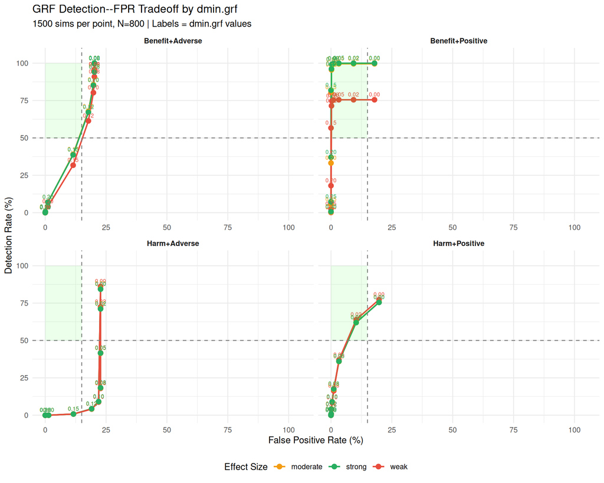

Detection rate vs FPR across dmin.grf values. Dashed lines mark the target zone (Det >= 50%, FPR <= 15%). Points in the upper-left quadrant achieve the target.

```r
if (nrow(sweep_results) > 0) {
  sweep_results$label <- sprintf("%.2f", sweep_results$dmin)

  ggplot(sweep_results,
         aes(x = FPR_H0, y = Det_H1, colour = Effect_Size)) +
    geom_line(aes(group = Effect_Size), linewidth = 0.8) +
    geom_point(size = 2.5) +
    geom_text(aes(label = label), vjust = -0.8, size = 2.3,
              show.legend = FALSE) +
    geom_hline(yintercept = target_det, linetype = "dashed",
               colour = "grey50") +
    geom_vline(xintercept = target_fpr, linetype = "dashed",
               colour = "grey50") +
    annotate("rect", xmin = 0, xmax = target_fpr,
             ymin = target_det, ymax = 100,
             alpha = 0.08, fill = "green") +
    facet_wrap(~ Scenario, ncol = 2, scales = "free_x") +
    scale_colour_manual(values = c(
      weak = "#e74c3c", moderate = "#f39c12", strong = "#27ae60")) +
    labs(
      x = "False Positive Rate (%)",
      y = "Detection Rate (%)",
      colour = "Effect Size",
      title = "GRF Detection--FPR Tradeoff by dmin.grf",
      subtitle = sprintf(
        "%d sims per point, N=%d | Labels = dmin.grf values",
        nsims, sim_n)
    ) +
    coord_cartesian(xlim = c(0, 105), ylim = c(0, 105)) +
    theme_minimal(base_size = 11) +
    theme(
      strip.text = element_text(face = "bold"),
      legend.position = "bottom"
    )
}
```

## 6.2 dmin.grf vs Detection / FPR

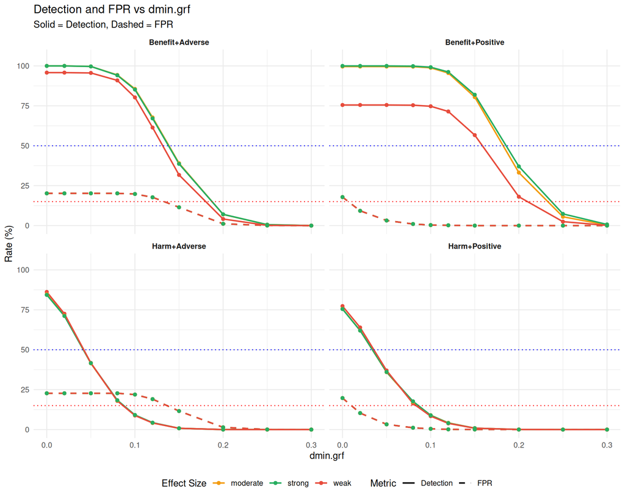

```r
if (nrow(sweep_results) > 0) {
  plot_df <- rbind(
    transform(sweep_results, Metric = "Detection", Rate = Det_H1),
    transform(sweep_results, Metric = "FPR", Rate = FPR_H0)
  )

  ggplot(plot_df, aes(x = dmin, y = Rate, colour = Effect_Size,
                      linetype = Metric)) +
    geom_line(linewidth = 0.8) +
    geom_point(size = 1.5) +
    geom_hline(yintercept = target_fpr, linetype = "dotted",
               colour = "red", linewidth = 0.5) +
    geom_hline(yintercept = target_det, linetype = "dotted",
               colour = "blue", linewidth = 0.5) +
    facet_wrap(~ Scenario, ncol = 2) +
    scale_linetype_manual(values = c(Detection = "solid", FPR = "dashed")) +
    scale_colour_manual(values = c(
      weak = "#e74c3c", moderate = "#f39c12", strong = "#27ae60")) +
    labs(
      x = "dmin.grf",
      y = "Rate (%)",
      colour = "Effect Size", linetype = "Metric",
      title = "Detection and FPR vs dmin.grf",
      subtitle = "Solid = Detection, Dashed = FPR"
    ) +
    coord_cartesian(ylim = c(0, 105)) +
    theme_minimal(base_size = 11) +
    theme(
      strip.text = element_text(face = "bold"),
      legend.position = "bottom"
    )
}
```

## 6.3 Full Results Table

```r
if (nrow(sweep_results) > 0) {
  sweep_results$Pass <- sweep_results$Det_H1 >= target_det &
                        sweep_results$FPR_H0 <= target_fpr

  sweep_results |>
    gt::gt() |>
    gt::tab_header(
      title = "GRF dmin.grf Calibration Results",
      subtitle = sprintf(
        "%d alt + %d null sims, N=%d | Target: Det >= %d%%, FPR <= %d%%",
        nsims, nsims, sim_n, target_det, target_fpr)
    ) |>
    gt::cols_label(
      Effect_Size = "Effect", OR_Q = "OR(Q)",
      dmin = "dmin.grf", Det_H1 = "Det %", FPR_H0 = "FPR %"
    ) |>
    gt::tab_style(
      style = gt::cell_fill(color = "#c8e6c9"),
      locations = gt::cells_body(rows = Pass == TRUE)
    ) |>
    gt::cols_hide(columns = c("Pass", "k_inter"))
}
```

GRF dmin.grf Calibration Results

1500 alt + 1500 null sims, N=800 | Target: Det >= 50%, FPR <= 15%

| Scenario | Effect | OR(Q) | dmin.grf | Det % | FPR % | label |
| --- | --- | --- | --- | --- | --- | --- |
| Harm+Adverse | weak | 2.61 | 0.00 | 86.20000000 | 22.73333333 | 0.00 |
| Harm+Adverse | weak | 2.61 | 0.02 | 72.53333333 | 22.73333333 | 0.02 |
| Harm+Adverse | weak | 2.61 | 0.05 | 41.73333333 | 22.73333333 | 0.05 |
| Harm+Adverse | weak | 2.61 | 0.08 | 17.93333333 | 22.73333333 | 0.08 |
| Harm+Adverse | weak | 2.61 | 0.10 | 8.80000000 | 21.93333333 | 0.10 |
| Harm+Adverse | weak | 2.61 | 0.12 | 4.13333333 | 19.06666667 | 0.12 |
| Harm+Adverse | weak | 2.61 | 0.15 | 0.80000000 | 11.60000000 | 0.15 |
| Harm+Adverse | weak | 2.61 | 0.20 | 0.00000000 | 1.40000000 | 0.20 |
| Harm+Adverse | weak | 2.61 | 0.25 | 0.00000000 | 0.06666667 | 0.25 |
| Harm+Adverse | weak | 2.61 | 0.30 | 0.00000000 | 0.00000000 | 0.30 |
| Harm+Adverse | moderate | 5.25 | 0.00 | 84.66666667 | 22.73333333 | 0.00 |
| Harm+Adverse | moderate | 5.25 | 0.02 | 71.40000000 | 22.73333333 | 0.02 |
| Harm+Adverse | moderate | 5.25 | 0.05 | 41.46666667 | 22.73333333 | 0.05 |
| Harm+Adverse | moderate | 5.25 | 0.08 | 18.20000000 | 22.73333333 | 0.08 |
| Harm+Adverse | moderate | 5.25 | 0.10 | 9.06666667 | 21.93333333 | 0.10 |
| Harm+Adverse | moderate | 5.25 | 0.12 | 4.20000000 | 19.06666667 | 0.12 |
| Harm+Adverse | moderate | 5.25 | 0.15 | 0.80000000 | 11.60000000 | 0.15 |
| Harm+Adverse | moderate | 5.25 | 0.20 | 0.00000000 | 1.40000000 | 0.20 |
| Harm+Adverse | moderate | 5.25 | 0.25 | 0.00000000 | 0.06666667 | 0.25 |
| Harm+Adverse | moderate | 5.25 | 0.30 | 0.00000000 | 0.00000000 | 0.30 |
| Harm+Adverse | strong | 14.27 | 0.00 | 84.33333333 | 22.73333333 | 0.00 |
| Harm+Adverse | strong | 14.27 | 0.02 | 71.13333333 | 22.73333333 | 0.02 |
| Harm+Adverse | strong | 14.27 | 0.05 | 41.60000000 | 22.73333333 | 0.05 |
| Harm+Adverse | strong | 14.27 | 0.08 | 18.40000000 | 22.73333333 | 0.08 |
| Harm+Adverse | strong | 14.27 | 0.10 | 9.13333333 | 21.93333333 | 0.10 |
| Harm+Adverse | strong | 14.27 | 0.12 | 4.33333333 | 19.06666667 | 0.12 |
| Harm+Adverse | strong | 14.27 | 0.15 | 0.80000000 | 11.60000000 | 0.15 |
| Harm+Adverse | strong | 14.27 | 0.20 | 0.00000000 | 1.40000000 | 0.20 |
| Harm+Adverse | strong | 14.27 | 0.25 | 0.00000000 | 0.06666667 | 0.25 |
| Harm+Adverse | strong | 14.27 | 0.30 | 0.00000000 | 0.00000000 | 0.30 |

[output cut: 90 more lines]

## 6.4 Optimal dmin.grf per Scenario

```r
if (nrow(sweep_results) > 0) {
  optimal_df <- data.frame()

  for (scen in unique(sweep_results$Scenario)) {
    for (es in unique(sweep_results$Effect_Size)) {
      sub <- sweep_results[sweep_results$Scenario == scen &
                            sweep_results$Effect_Size == es, ]
      good <- sub[sub$Det_H1 >= target_det & sub$FPR_H0 <= target_fpr, ]

      if (nrow(good) > 0) {
        best <- good[which.min(good$dmin), ]
        optimal_df <- rbind(optimal_df, data.frame(
          Scenario = scen, Effect_Size = es,
          OR_Q = best$OR_Q,
          Optimal_dmin = best$dmin,
          Detection = best$Det_H1,
          FPR = best$FPR_H0,
          Status = "Achieved",
          stringsAsFactors = FALSE))
      } else {
        sub$score <- sub$Det_H1 - 2 * sub$FPR_H0
        best_trade <- sub[which.max(sub$score), ]
        optimal_df <- rbind(optimal_df, data.frame(
          Scenario = scen, Effect_Size = es,
          OR_Q = best_trade$OR_Q,
          Optimal_dmin = best_trade$dmin,
          Detection = best_trade$Det_H1,
          FPR = best_trade$FPR_H0,
          Status = "Best tradeoff",
          stringsAsFactors = FALSE))
      }
    }
  }

  optimal_df |>
    gt::gt() |>
    gt::tab_header(
      title = "Optimal dmin.grf by Scenario and Effect Size",
      subtitle = sprintf("Target: Det >= %d%% AND FPR <= %d%%",
        target_det, target_fpr)
    ) |>
    gt::tab_style(
      style = gt::cell_fill(color = "#c8e6c9"),
      locations = gt::cells_body(rows = Status == "Achieved")
    ) |>
    gt::tab_style(
      style = gt::cell_fill(color = "#fff9c4"),
      locations = gt::cells_body(rows = Status == "Best tradeoff")
    )
}
```

Optimal dmin.grf by Scenario and Effect Size

Target: Det >= 50% AND FPR <= 15%

| Scenario | Effect_Size | OR_Q | Optimal_dmin | Detection | FPR | Status |
| --- | --- | --- | --- | --- | --- | --- |
| Harm+Adverse | weak | 2.61 | 0.00 | 86.20000 | 22.733333 | Best tradeoff |
| Harm+Adverse | moderate | 5.25 | 0.00 | 84.66667 | 22.733333 | Best tradeoff |
| Harm+Adverse | strong | 14.27 | 0.00 | 84.33333 | 22.733333 | Best tradeoff |
| Harm+Positive | weak | 2.74 | 0.02 | 63.93333 | 10.333333 | Achieved |
| Harm+Positive | moderate | 5.51 | 0.02 | 62.00000 | 10.333333 | Achieved |
| Harm+Positive | strong | 14.97 | 0.02 | 62.00000 | 10.333333 | Achieved |
| Benefit+Positive | weak | 1.11 | 0.02 | 75.53333 | 9.266667 | Achieved |
| Benefit+Positive | moderate | 2.23 | 0.02 | 99.60000 | 9.266667 | Achieved |
| Benefit+Positive | strong | 6.06 | 0.02 | 100.00000 | 9.266667 | Achieved |
| Benefit+Adverse | weak | 1.36 | 0.00 | 95.80000 | 20.200000 | Best tradeoff |
| Benefit+Adverse | moderate | 2.74 | 0.00 | 100.00000 | 20.200000 | Best tradeoff |
| Benefit+Adverse | strong | 7.42 | 0.00 | 100.00000 | 20.200000 | Best tradeoff |

## 6.5 Mean FPR by dmin.grf

```r
if (nrow(sweep_results) > 0) {
  mean_by_dmin <- do.call(rbind, lapply(dmin_grid, function(d) {
    sub <- sweep_results[sweep_results$dmin == d, ]
    data.frame(
      dmin = d,
      Mean_Det = round(mean(sub$Det_H1, na.rm = TRUE), 1),
      Mean_FPR = round(mean(sub$FPR_H0, na.rm = TRUE), 1),
      stringsAsFactors = FALSE
    )
  }))

  mean_by_dmin |>
    gt::gt() |>
    gt::tab_header(
      title = "Mean Detection and FPR by dmin.grf",
      subtitle = "Averaged across all scenarios and effect sizes"
    ) |>
    gt::tab_style(
      style = gt::cell_fill(color = "#e8f5e9"),
      locations = gt::cells_body(
        rows = Mean_FPR <= target_fpr)
    )
}
```

Mean Detection and FPR by dmin.grf

Averaged across all scenarios and effect sizes

| dmin | Mean_Det | Mean_FPR |
| --- | --- | --- |
| 0.00 | 87.9 | 20.1 |
| 0.02 | 81.2 | 15.6 |
| 0.05 | 67.0 | 12.3 |
| 0.08 | 55.0 | 11.3 |
| 0.10 | 48.1 | 10.6 |
| 0.12 | 40.4 | 9.3 |
| 0.15 | 27.8 | 5.8 |
| 0.20 | 8.9 | 0.6 |
| 0.25 | 1.4 | 0.0 |
| 0.30 | 0.1 | 0.0 |

# 7 Phase 1 Reference: Best Configurations

```r
if (nrow(best_df) > 0) {
  best_df |>
    gt::gt() |>
    gt::tab_header(
      title = "Phase 1: Recommended GRF Configuration per Scenario",
      subtitle = "From single-dataset configuration discovery"
    ) |>
    gt::tab_footnote(
      footnote = paste(
        "Treatment = 'treat' (direct) or 'treat_sw' (switched).",
        "Adverse_Outcome controls the 1-Y flip before causal_forest().")
    )
}
```

Phase 1: Recommended GRF Configuration per Scenario

From single-dataset configuration discovery

| Scenario | Treatment | Adverse_Outcome | Detected | Sensitivity | PPV | Subgroup |
| --- | --- | --- | --- | --- | --- | --- |
| Harm+Adverse | treat_sw | FALSE | TRUE | 1 | 1.00 | z1 <= 0 & z2 <= 0 |
| Harm+Positive | treat | FALSE | TRUE | 1 | 1.00 | z2 <= 0 & z1 <= 0 |
| Benefit+Positive | treat_sw | FALSE | TRUE | 1 | 0.33 | z1 <= 0 & z4 <= 0 |
| Benefit+Adverse | treat | FALSE | TRUE | 1 | 0.50 | z1 <= 0 |

Treatment = 'treat' (direct) or 'treat_sw' (switched). Adverse_Outcome controls the 1-Y flip before causal_forest().

# 8 Timing

```r
elapsed <- (proc.time() - t_start)["elapsed"]
cat(sprintf("Total document render time: %.1f minutes (%.0f seconds)\n",
    elapsed / 60, elapsed))
```

```
#> Total document render time: 73.2 minutes (4394 seconds)
```

```r
cat(sprintf("Configuration: %d sims × %d dmin values × %d effect sizes × %d scenarios\n",
    nsims, length(dmin_grid), length(k_inter_levels),
    length(unique(sweep_results$Scenario))))
```

```
#> Configuration: 1500 sims × 10 dmin values × 3 effect sizes × 4 scenarios
```

```r
cat(sprintf("Total GRF calls: ~%d\n",
    2 * nsims * length(dmin_grid) * length(k_inter_levels) *
    length(unique(sweep_results$Scenario))))
```

```
#> Total GRF calls: ~360000
```